# Sensitivity Analysis of Carbondate Assumption Zn BLM

Cecilia Albert-Black

# Objectives

Two scenarios will be compared to conduct a sensitivity analysis of BLM’s carbonate system assumptions:

- **Baseline**: Closed system, measured DIC as a BLM input variable
- **Perturbed**: Open system, no DIC input. Instead, BLM estimates alkalinity by charge balance using pH and assuming in equilibrium with atmospheric partial pressure

# 1. Setup

Set working directory

```r
setwd("C:/Users/q4q/OneDrive - Oak Ridge National Laboratory/Research/Bioavailability Project/BLM_spatial_assessmt/Zinc/6. Sensitivity analyses")
```

Merge BLM output variables from the baseline conditions (closed system + HA 10%) and the perturbed scenario (open system + HA 10% ) from the clean Bioavailability Master Spreadsheet version 2 (pre-typology) and version 3 (with typological classification).

First, set the working directory and import each dataset as it’s own object

```r
library(readxl)

# -------------------------------------------------
# 1) Set working directory
# -------------------------------------------------
setwd("C:/Users/q4q/OneDrive - Oak Ridge National Laboratory/Research/Bioavailability Project/BLM_spatial_assessmt/Zinc/6. Sensitivity analyses")

# -------------------------------------------------
# 2) Store file paths once (so you don't repeat them)
# -------------------------------------------------
file_master3 <- "C:/Users/q4q/OneDrive - Oak Ridge National Laboratory/Research/Bioavailability Project/BLM_spatial_assessmt/Zinc/5. Statistical data analysis/Bioavailability_Master_Spreadsheet_Clean3.xlsx"

file_master2 <- "C:/Users/q4q/OneDrive - Oak Ridge National Laboratory/Research/Bioavailability Project/BLM_spatial_assessmt/Zinc/4. Exploratory data analysis/Bioavailability_Master_Spreadsheet_Clean2.xlsx"

library(dplyr)
read_scenario <- function(path, sheet) {
  read_excel(path, sheet = sheet)
}

ha_10_cs <- read_scenario(file_master3, "HA 10% Closed System")
ha_10_os <- read_scenario(file_master2, "HA 10% Open System")
```

Add typology from ha_10_cs to each scenario

```r
library(dplyr)

typology_lookup <- ha_10_cs %>%
  dplyr::select(Sample_ID, Typology) %>%
  distinct()

ha_10_os <- ha_10_os %>%
  left_join(typology_lookup, by = "Sample_ID") %>%
  dplyr::select(Sample_ID, Typology, everything())

ha_10_cs <- ha_10_cs %>%
  dplyr::select(Sample_ID, Typology, everything())

# quick sanity check: check if there are Sample_IDs that don't match (should be 0)
setdiff(ha_10_os$Sample_ID, ha_10_cs$Sample_ID)
```

```
##  [1] "WaDE_65"  "WaDE_86"  "WaDE_87"  "WaDE_130" "WaDE_165" "WaDE_193"
##  [7] "WaDE_264" "WaDE_268" "WaDE_328" "WaDE_329" "WaDE_338" "WaDE_339"
## [13] "WaDE_368" "WaDE_369" "WaDE_392" "WaDE_420" "WaDE_442" "WaDE_448"
## [19] "WaDE_475" "WaDE_476" "WaDE_477" "WaDE_478" "WaDE_508" "WaDE_553"
## [25] "WaDE_593" "WaDE_635" "WaDE_663" "WaDE_665" "WaDE_717" "WaDE_730"
```

# 2. Select variables of interest

Create a paired dataset

```r
library(dplyr)

# Only retain BLM speciation mode output variables in nM and nmol/g for simplicity and consistency (one column per variable and all in same units of measurement)
ha_10_cs <- ha_10_cs %>%
  dplyr::select(
    Sample_ID,
    ends_with("_nM"),
    ends_with("_nmol_kg"),
    # log-transformed variables
    -starts_with("log_"),
    # Remove BLM predictors
    -"DOC_nM",
    -"Ca_nM",
    -"Mg_nM",
    -"Na_nM",
    -"K_nM",
    -"SO4_nM",
    -"Cl_nM",
    -"pH",
    -"DIC_nM",
    -"Zn_nM",
    -"Cu_nM",
    # Remove toxicity variables
    -ends_with("_tox_nM")
  )

ha_10_os <- ha_10_os %>%
  dplyr::select(
    Sample_ID,
    ends_with("_nM"),
    ends_with("_nmol_kg"),
    # log-transformed variables
    -starts_with("log_"),
    # BLM predictors
    -"DOC_nM",
    -"Ca_nM",
    -"Mg_nM",
    -"Na_nM",
    -"K_nM",
    -"SO4_nM",
    -"Cl_nM",
    -"pH",
    -"DIC_nM",
    -"Zn_nM",
    -"Cu_nM",
    # Remove toxicity variables
   )

library(dplyr)

# Keep only Sample_IDs present in BOTH datasets

common_ids <- intersect(ha_10_cs$Sample_ID, ha_10_os$Sample_ID)

ha_10_cs <- ha_10_cs %>%
  filter(Sample_ID %in% common_ids) %>%
  arrange(Sample_ID)

ha_10_os <- ha_10_os %>%
  filter(Sample_ID %in% common_ids) %>%
  arrange(Sample_ID)


# 2) Check that the numeric columns match

names_cs <- ha_10_cs %>% select(where(is.numeric)) %>% names()
names_os <- ha_10_os %>% select(where(is.numeric)) %>% names()

setdiff(names_cs, names_os)
```

```
## character(0)
```

```r
setdiff(names_os, names_cs)
```

```
## character(0)
```

Create bioavailabile Zn variable in each dataset

```r
ha_10_cs <- ha_10_cs %>%
  mutate(
    TBL_Zn_nmol_kg = BL_Zn_nmol_kg + BL_ZnOH_nmol_kg
  )

ha_10_os <- ha_10_os %>%
  mutate(
    TBL_Zn_nmol_kg = BL_Zn_nmol_kg + BL_ZnOH_nmol_kg
  )
```

# 3. Calculate sensitivity metrics

## i. Delta

Delta is the absolute change in a response variable from baseline to the perturbed BLM system assumptions; calculated as y_s2 - y_s1.

```r
library(dplyr)
library(stringr)

# 1. Separate the numeric data
num1 <- ha_10_cs %>%
  dplyr::select(where(is.numeric))

num2 <- ha_10_os %>%
  dplyr::select(where(is.numeric))

# 2. Subtract num1-num2
delta_dic <- ha_10_os %>%
  dplyr::select(Sample_ID) %>%
  bind_cols(num2 - num1)

# 3. Check
delta_dic
```

```
## # A tibble: 356 × 32
##    Sample_ID Free_Zn_nM  ZnOH_nM Zn_OH_2_nM ZnCO3_nM ZnHCO3_nM ZnSO4_nM  ZnCl_nM
##    <chr>          <dbl>    <dbl>      <dbl>    <dbl>     <dbl>    <dbl>    <dbl>
##  1 WaDE_108     -4.52   -3.13     -25.6      65.5       10.9   -0.219   -4.57e-3
##  2 WaDE_122      4.24    0.115      0.0362   -2.04     -10.6    0.109    2.19e-3
##  3 WaDE_123      1.10    0.0231     0.00511  -0.734     -5.03   0.0121   1.42e-4
##  4 WaDE_124      1.76    0.0550     0.0191   -1.69      -8.39   0.0355   1.31e-3
##  5 WaDE_125      2.91    0.0877     0.0298   -2.10     -10.4    0.0503   1.82e-3
##  6 WaDE_126      0.291   0.00944    0.00330  -0.302     -1.35   0.00339  3.25e-5
##  7 WaDE_127      0.0626  0.00244    0.00104  -0.0667    -0.266  0.00103  8.49e-6
##  8 WaDE_128      1.79    0.0652     0.0266   -1.74      -7.49   0.0318   1.14e-3
##  9 WaDE_129      1.31    0.0489     0.0201   -1.53      -6.60   0.0237   8.71e-4
## 10 WaDE_131      0.545   0.0364     0.0272   -1.07      -2.56   0.0119   2.67e-4
## # ℹ 346 more rows
## # ℹ 24 more variables: ZnS_nM <dbl>, TOrg_Zn_nM <dbl>, HCO3_nM <dbl>,
## #   H2_CO3_nM <dbl>, HS_nM <dbl>, H2S_nM <dbl>, MgHCO3_nM <dbl>,
## #   MgCO3_nM <dbl>, MgSO4_nM <dbl>, CaHCO3_nM <dbl>, CaCO3_nM <dbl>,
## #   CaSO4_nM <dbl>, TOrg_H_nM <dbl>, TOrg_Ca_nM <dbl>, TOrg_Mg_nM <dbl>,
## #   TOrg_Na_nM <dbl>, TOrg_K_nM <dbl>, BL_Zn_nmol_kg <dbl>,
## #   BL_Ca_nmol_kg <dbl>, BL_H_nmol_kg <dbl>, BL_Mg_nmol_kg <dbl>, …
```

Summarize delta by variable

```r
library(dplyr)
library(tidyr)

summary_delta_dic <- delta_dic %>%
  dplyr::select(where(is.numeric)) %>%
  summarise(across(everything(), list(
    min    = ~min(.x, na.rm = TRUE),
    q1     = ~quantile(.x, 0.25, na.rm = TRUE),
    median = ~median(.x, na.rm = TRUE),
    mean   = ~mean(.x, na.rm = TRUE),
    q3     = ~quantile(.x, 0.75, na.rm = TRUE),
    max    = ~max(.x, na.rm = TRUE),
    iqr    = ~IQR(.x, na.rm = TRUE)
  ))) %>%
  # Pivot so it's a readable list instead of 500 columns wide
  pivot_longer(everything(),
               names_to = c("Variable", ".value"),
               names_sep = "_(?!.*_)") # Splits at the last underscore

# Check
head(summary_delta_dic)
```

```
## # A tibble: 6 × 8
##   Variable        min        q1   median     mean      q3     max     iqr
##   <chr>         <dbl>     <dbl>    <dbl>    <dbl>   <dbl>   <dbl>   <dbl>
## 1 Free_Zn_nM  -15.4     1.11      4.09     7.19    9.45    73.4    8.34
## 2 ZnOH_nM      -5.49    0.0270    0.0791   0.0447  0.166    0.836  0.139
## 3 Zn_OH_2_nM  -85.7     0.00424   0.0170  -0.612   0.0452   1.01   0.0409
## 4 ZnCO3_nM    -15.8    -3.40     -1.90    -0.638  -0.892  131.     2.51
## 5 ZnHCO3_nM  -109.    -20.4     -13.6    -14.5    -4.77    29.2   15.7
## 6 ZnSO4_nM     -0.571   0.0167    0.0527   0.0707  0.109    0.694  0.0924
```

## ii. Percent change

Percentage of delta

```r
# Multiply all numeric columns by 100
percent_change_dic <- delta_dic %>%
  dplyr::select(where(is.numeric)) * 100

# Check
head(percent_change_dic)
```

```
##   Free_Zn_nM      ZnOH_nM    Zn_OH_2_nM   ZnCO3_nM  ZnHCO3_nM    ZnSO4_nM
## 1 -452.34412 -313.4471460 -2556.9263151 6554.35102  1090.9676 -21.8658945
## 2  424.19730   11.5193383     3.6246652 -203.70071 -1062.9412  10.8819204
## 3  109.92665    2.3109001     0.5112674  -73.36732  -503.3670   1.2067451
## 4  176.40449    5.4976801     1.9101346 -169.30785  -839.2409   3.5504211
## 5  291.17171    8.7745089     2.9826544 -209.64928 -1038.1298   5.0326576
## 6   29.10159    0.9438304     0.3299902  -30.20155  -134.9754   0.3387349
##        ZnCl_nM        ZnS_nM TOrg_Zn_nM    HCO3_nM H2_CO3_nM         HS_nM
## 1 -0.456560983  0.000000e+00 -4302.1066 1769209700   2408483  1.151656e-10
## 2  0.218911868  8.801202e-11   816.2765 -220707047 -10331825 -2.529610e-10
## 3  0.014163562  8.801202e-11   462.7623 -102206683  -6731471 -1.297059e-10
## 4  0.131156631  8.801202e-11   820.7668 -180672685  -8075245 -1.488606e-10
## 5  0.181639946 -1.316872e-10   939.7316 -184326223  -8269807 -1.490155e-10
## 6  0.003252522  4.830735e-10   134.4341 -125854631  -5278106 -4.312681e-10
##          H2S_nM MgHCO3_nM    MgCO3_nM    MgSO4_nM  CaHCO3_nM   CaCO3_nM
```

[output cut: 27 more lines]

Check the distribution of the percent change

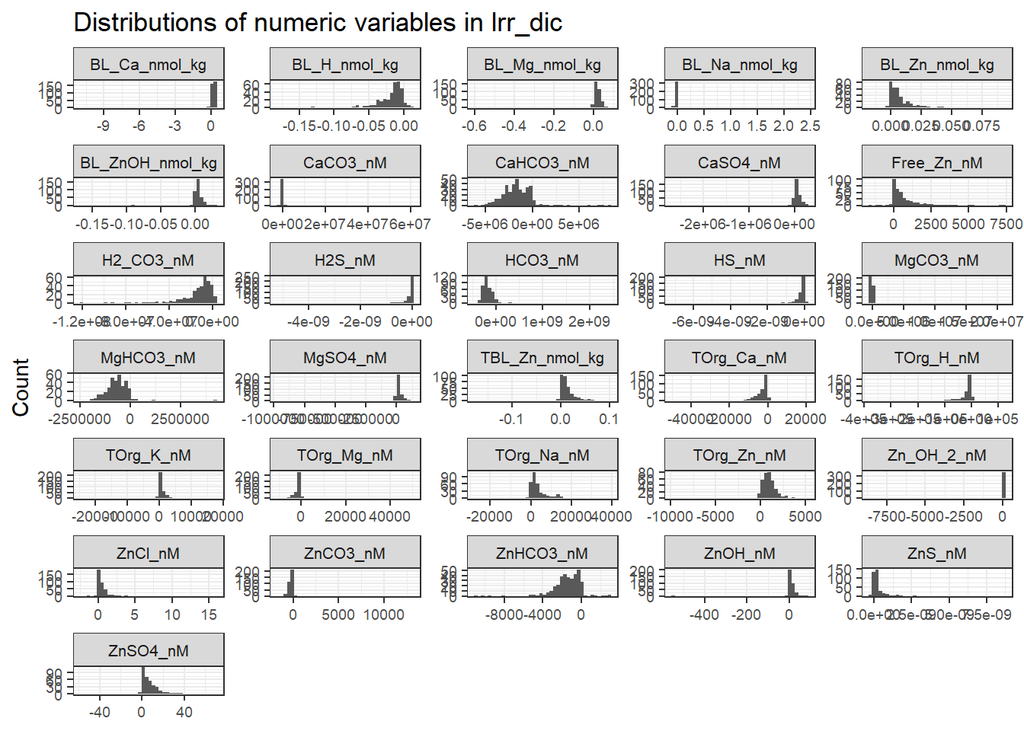

```r
library(dplyr)
library(tidyr)
library(ggplot2)
percent_change_dic %>%
  select(where(is.numeric)) %>%
  pivot_longer(
    cols = everything(),
    names_to = "variable",
    values_to = "value"
  ) %>%
  ggplot(aes(x = value)) +
  geom_histogram(bins = 40, na.rm = TRUE) +
  facet_wrap(~ variable, scales = "free", ncol = 5) +
  labs(
    title = "Distributions of numeric variables in lrr_dic",
    x = NULL,
    y = "Count"
  ) +
  theme_bw() +
  theme(
    strip.text = element_text(size = 8),
    axis.text.x = element_text(size = 7),
    axis.text.y = element_text(size = 7)
  )
```

Summarize percent change by variable

```r
library(dplyr)
library(tidyr)

summary_percent_change_dic <- percent_change_dic %>%
  dplyr::select(where(is.numeric)) %>%
  summarise(across(everything(), list(
    min    = ~min(.x, na.rm = TRUE),
    q1     = ~quantile(.x, 0.25, na.rm = TRUE),
    median = ~median(.x, na.rm = TRUE),
    mean   = ~mean(.x, na.rm = TRUE),
    q3     = ~quantile(.x, 0.75, na.rm = TRUE),
    max    = ~max(.x, na.rm = TRUE),
    iqr    = ~IQR(.x, na.rm = TRUE)
  ))) %>%
  # Pivot so it's a readable list instead of 500 columns wide
  pivot_longer(everything(),
               names_to = c("Variable", ".value"),
               names_sep = "_(?!.*_)") # Splits at the last underscore

# Check
head(summary_percent_change_dic)
```

```
## # A tibble: 6 × 8
##   Variable        min        q1   median     mean      q3     max     iqr
##   <chr>         <dbl>     <dbl>    <dbl>    <dbl>   <dbl>   <dbl>   <dbl>
## 1 Free_Zn_nM  -1538.    111.      409.     719.    945.    7335.   834.
## 2 ZnOH_nM      -549.      2.70      7.91     4.47   16.6     83.6   13.9
## 3 Zn_OH_2_nM  -8570.      0.424     1.70   -61.2     4.52   101.     4.09
## 4 ZnCO3_nM    -1580.   -340.     -190.     -63.8   -89.2  13089.   251.
## 5 ZnHCO3_nM  -10923.  -2042.    -1357.   -1453.   -477.    2917.  1565.
## 6 ZnSO4_nM      -57.1     1.67      5.27     7.07   10.9     69.4    9.24
```

## iii. Log response ratio (LRR)

LRR describes the effect size between the two BLM assumption outputs, calculated as

log10(y_s2) - log10(y_s1)

```r
library(dplyr)

# 1. Log transform each dataframe
log_ha_10_cs <- ha_10_cs %>%
  mutate(across(where(is.numeric), log10))

log_ha_10_os <- ha_10_os %>%
  mutate(across(where(is.numeric), log10))

# 2. Separate the numeric log-transformed data
log_num1 <- log_ha_10_cs %>%
  dplyr::select(where(is.numeric))

log_num2 <- log_ha_10_os %>%
  dplyr::select(where(is.numeric))

# 3. Subtract num1-num2
lrr_dic <- ha_10_os %>%
  dplyr::select(Sample_ID) %>%
  bind_cols(log_num2 - log_num1)

# 4. Check
head(lrr_dic)
```

```
## # A tibble: 6 × 32
##   Sample_ID Free_Zn_nM ZnOH_nM Zn_OH_2_nM ZnCO3_nM ZnHCO3_nM ZnSO4_nM ZnCl_nM
##   <chr>          <dbl>   <dbl>      <dbl>    <dbl>     <dbl>    <dbl>   <dbl>
## 1 WaDE_108     -0.419  -0.465     -0.484     0.406     0.425  -0.511  -0.485
## 2 WaDE_122      0.120   0.128      0.131    -0.583    -0.586   0.137   0.131
## 3 WaDE_123      0.0374  0.0433     0.0456   -0.511    -0.513   0.0517  0.0457
## 4 WaDE_124      0.0593  0.0662     0.0689   -0.565    -0.568   0.0744  0.0690
## 5 WaDE_125      0.0777  0.0850     0.0878   -0.552    -0.555   0.0937  0.0879
## 6 WaDE_126      0.0434  0.0495     0.0518   -0.435    -0.437   0.0575  0.0520
## # ℹ 24 more variables: ZnS_nM <dbl>, TOrg_Zn_nM <dbl>, HCO3_nM <dbl>,
## #   H2_CO3_nM <dbl>, HS_nM <dbl>, H2S_nM <dbl>, MgHCO3_nM <dbl>,
## #   MgCO3_nM <dbl>, MgSO4_nM <dbl>, CaHCO3_nM <dbl>, CaCO3_nM <dbl>,
## #   CaSO4_nM <dbl>, TOrg_H_nM <dbl>, TOrg_Ca_nM <dbl>, TOrg_Mg_nM <dbl>,
## #   TOrg_Na_nM <dbl>, TOrg_K_nM <dbl>, BL_Zn_nmol_kg <dbl>,
## #   BL_Ca_nmol_kg <dbl>, BL_H_nmol_kg <dbl>, BL_Mg_nmol_kg <dbl>,
## #   BL_Na_nmol_kg <dbl>, BL_ZnOH_nmol_kg <dbl>, TBL_Zn_nmol_kg <dbl>
```

Check distribution of LRRs

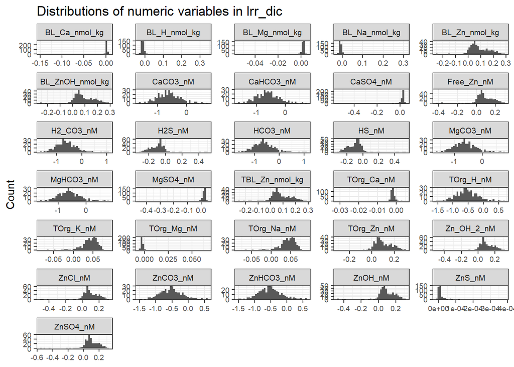

```r
library(dplyr)
library(tidyr)
library(ggplot2)

lrr_dic %>%
  select(where(is.numeric)) %>%
  pivot_longer(
    cols = everything(),
    names_to = "variable",
    values_to = "value"
  ) %>%
  ggplot(aes(x = value)) +
  geom_histogram(bins = 40, na.rm = TRUE) +
  facet_wrap(~ variable, scales = "free", ncol = 5) +
  labs(
    title = "Distributions of numeric variables in lrr_dic",
    x = NULL,
    y = "Count"
  ) +
  theme_bw() +
  theme(
    strip.text = element_text(size = 8),
    axis.text.x = element_text(size = 7),
    axis.text.y = element_text(size = 7)
  )
```

Summarize LRR for each numeric variable

```r
library(dplyr)
library(tidyr)

summary_lrr_dic <- lrr_dic %>%
  dplyr::select(where(is.numeric)) %>%
  summarise(across(everything(), list(
    min    = ~min(.x, na.rm = TRUE),
    q1     = ~quantile(.x, 0.25, na.rm = TRUE),
    median = ~median(.x, na.rm = TRUE),
    mean   = ~mean(.x, na.rm = TRUE),
    q3     = ~quantile(.x, 0.75, na.rm = TRUE),
    max    = ~max(.x, na.rm = TRUE),
    iqr    = ~IQR(.x, na.rm = TRUE)
  ))) %>%
  # Pivot so it's a readable list instead of 500 columns wide
  pivot_longer(everything(),
               names_to = c("Variable", ".value"),
               names_sep = "_(?!.*_)") # Splits at the last underscore

# Check
head(summary_lrr_dic)
```

```
## # A tibble: 6 × 8
##   Variable      min      q1  median    mean     q3   max   iqr
##   <chr>       <dbl>   <dbl>   <dbl>   <dbl>  <dbl> <dbl> <dbl>
## 1 Free_Zn_nM -0.419  0.0423  0.0739  0.0886  0.150 0.291 0.108
## 2 ZnOH_nM    -0.467  0.0484  0.0817  0.0947  0.159 0.304 0.110
## 3 Zn_OH_2_nM -0.498  0.0506  0.0844  0.0971  0.162 0.308 0.112
## 4 ZnCO3_nM   -1.49  -0.759  -0.540  -0.527  -0.314 0.573 0.444
## 5 ZnHCO3_nM  -1.49  -0.762  -0.542  -0.529  -0.316 0.591 0.446
## 6 ZnSO4_nM   -0.552  0.0557  0.0902  0.102   0.170 0.318 0.114
```

## iv. Robustness

To assess directional consistency in LRR, we’ll summarize how many variables had a + or - LRR for each variable

```r
library(dplyr)

robustness_dic <- lrr_dic %>%
  dplyr::select(where(is.numeric)) %>%
  summarize(across(everything(), list(
    positive = ~sum(.x > 0, na.rm = TRUE),
    negative = ~sum(.x < 0, na.rm = TRUE),
    zero = ~sum(.x == 0, na.rm = TRUE)
  ))) %>%
  # Pivot for readability
  pivot_longer(everything(),
               names_to = c("Variable", ".value"),
               names_sep = "_(?!.*_)") %>%
  # Add the ratio of positive/negative LRR values
  mutate(ratio = positive/negative)

# Check
head(robustness_dic)
```

```
## # A tibble: 6 × 5
##   Variable   positive negative  zero   ratio
##   <chr>         <int>    <int> <int>   <dbl>
## 1 Free_Zn_nM      335       21     0 16.0
## 2 ZnOH_nM         335       21     0 16.0
## 3 Zn_OH_2_nM      335       21     0 16.0
## 4 ZnCO3_nM         22      334     0  0.0659
## 5 ZnHCO3_nM        22      334     0  0.0659
## 6 ZnSO4_nM        334       22     0 15.2
```

# 4. Export SA results

Now we’ll compile all of the output to one excel sheet

```r
library(openxlsx)

# Create a list of all output objects
dic_sa_list <- list(
  "Delta"              = summary_delta_dic,
  "Percent Change"     = summary_percent_change_dic,
  "Log Response Ratio" = summary_lrr_dic,
  "Robustness"         = robustness_dic
)

# Write into excel file
write.xlsx(dic_sa_list, file = "Carbonate_system_SA.xlsx", overwrite = TRUE)
```

# 5. Plots

Since the percent changes were not normally distributed, we’ll plot the median and inter quartile ranges (IQRs) for each variable

## i. Percent change

```r
library(dplyr)

# 1. Pivot table: turn columns into rows
long_percent_change_dic <- percent_change_dic %>%
  pivot_longer(cols = everything(),
               names_to = "Variable",
               values_to = "Value") %>%
  # Calculate the stats
  group_by(Variable) %>%
  summarize(
    median = median(Value, na.rm = TRUE),
    q1 = quantile(Value, 0.25, na.rm = TRUE),
    q3 = quantile(Value, 0.75, na.rm = TRUE)
  ) %>%
  # Sort variables by median value
  mutate(Variable = reorder(Variable, median))


# 2. Plot
library(ggplot2)

pc_plot <- ggplot(long_percent_change_dic, aes(y = Variable, x = median)) +
  geom_col(aes(fill = median)) +
  geom_errorbar(aes(xmin = q1, xmax = q3), width = 0.25) +
  geom_vline(xintercept = 0, linetype = "dashed", color = "grey40") +
  scale_fill_gradient2(
    low = "red3", mid = "grey95", high = "steelblue4", midpoint = 0) +
  labs(x = "Percent Change (Median ± IQR)", y = NULL,
       title = "Percent Change Summary for Zn BLM",
       subtitle = "Closed system to open system BLM") +
  theme_bw() +
  theme(axis.text.y = element_text(size = 8)) +
  guides(fill = "none")

# 3. Save plot

# Define output directory
out_dir <- "Plots of DIC SA"

# Create folder if it doesn't exist
if (!dir.exists(out_dir)) {
  dir.create(out_dir, recursive = TRUE)
}

# Save plot
ggsave(
  filename = file.path(out_dir, "Percent_Change_DIC_SA.png"),
  plot = pc_plot,
  width = 10,
  height = 8,
  units = "in",
  dpi = "print"
)
```

## ii. LRR

Since the LRRs were not normally distributed, we’ll plot the median and inter quartile ranges (IQRs) for each variable

```r
library(dplyr)

# 1. Pivot table: turn columns into rows
long_lrr_dic <- lrr_dic %>%
  pivot_longer(cols = -Sample_ID,
               names_to = "Variable",
               values_to = "Value") %>%
  # Calculate the stats
  group_by(Variable) %>%
  summarize(
    median = median(Value, na.rm = TRUE),
    q1 = quantile(Value, 0.25, na.rm = TRUE),
    q3 = quantile(Value, 0.75, na.rm = TRUE)
  ) %>%
  # Sort variables by median value
  mutate(Variable = reorder(Variable, median))


# 2. Plot
library(ggplot2)

lrr_plot <- ggplot(long_lrr_dic, aes(y = Variable, x = median)) +
  geom_col(aes(fill = median)) +
  geom_errorbar(aes(xmin = q1, xmax = q3), width = 0.25) +
  geom_vline(xintercept = 0, linetype = "dashed", color = "grey40") +
  scale_fill_gradient2(
    low = "red3", mid = "grey95", high = "steelblue4", midpoint = 0) +
  labs(x = "LRR (Median ± IQR)", y = NULL,
       title = "Log Response Ratio (LRR) Summary for Zn BLM",
       subtitle = "Closed system to open system BLM") +
  theme_bw() +
  theme(axis.text.y = element_text(size = 8)) +
  guides(fill = "none")

# 3. Save plot
out_dir <- "Plots of DIC SA"
# Save plot
ggsave(
  filename = file.path(out_dir, "LRR_DIC_SA.png"),
  plot = lrr_plot,
  width = 10,
  height = 8,
  units = "in",
  dpi = "print"
)
```